# Introducción al Lenguaje R

Santiago Benitez-Vieyra

## Introducción a los Modelos Lineales

[figure not shown]

**Es Solo Un Modelo Lineal! (ESUML!)**

## Qué es un modelo?

[figure not shown]

https://xkcd.com/2355/

[Statistical learning](http://faculty.marshall.usc.edu/gareth-james/ISL/)  
Herramientas para modelar y entender datos complejos. Resolver el problema de encontrar una función predictiva a partir de los datos.

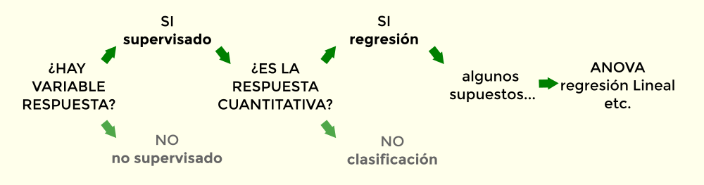

## Modelos Lineales

## Modelos Lineales

Respuesta = Modelo + Error
$$Y_{i} = \beta_{0} + \beta_{1}X_{1i} + \epsilon_{i}$$

- El modelo es lineal porque los parámetros se combinan linealmente.
- Ningún parámetro es multiplicado o dividido por otro o aparece como exponente.
- Las variables independientes pueden ser no-lineales (por lo cual el modelo lineal puede representar relaciones curvilíneas).

## Regresión lineal simple

$$Y_{i} = \beta_{0} + \beta_{1}X_{1i} + \epsilon_{i}$$
$$X_{i} \sim continua$$

- Dos variables están relacionadas. Una de ellas informa sobre la otra
- La variable independiente brinda una explicación sobre la dependiente
- La variable independiente causa la dependiente

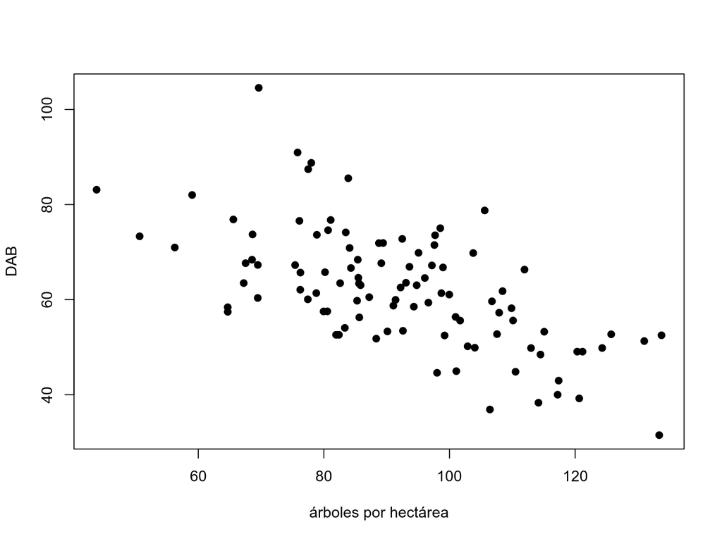

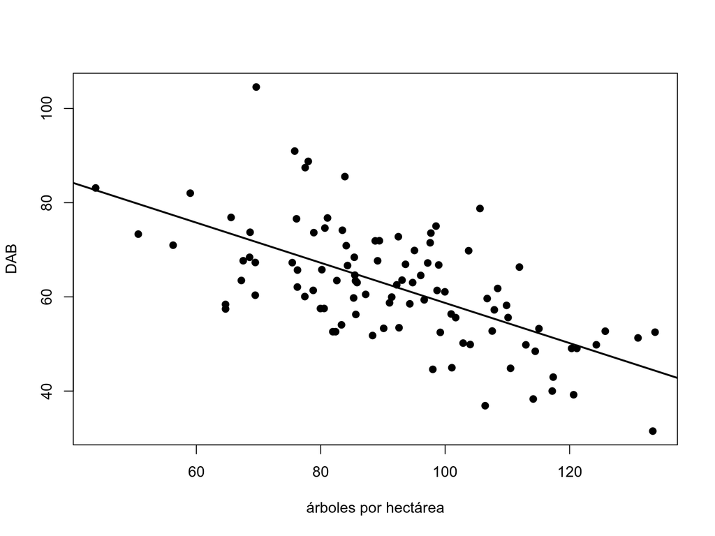

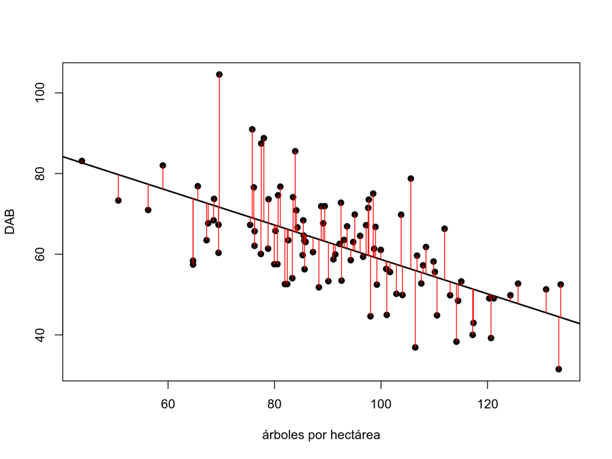

```
Call:
lm(formula = Y ~ X)

Residuals:
    Min      1Q  Median      3Q     Max
-19.073  -6.835  -0.875   5.806  32.904

Coefficients:
             Estimate Std. Error t value Pr(>|t|)
(Intercept) 101.33319    5.00127  20.261  < 2e-16 ***
X            -0.42624    0.05344  -7.976 2.85e-12 ***
---
Signif. codes:  0 '***' 0.001 '**' 0.01 '*' 0.05 '.' 0.1 ' ' 1

Residual standard error: 9.707 on 98 degrees of freedom
Multiple R-squared:  0.3936,    Adjusted R-squared:  0.3874
F-statistic: 63.62 on 1 and 98 DF,  p-value: 2.853e-12
```

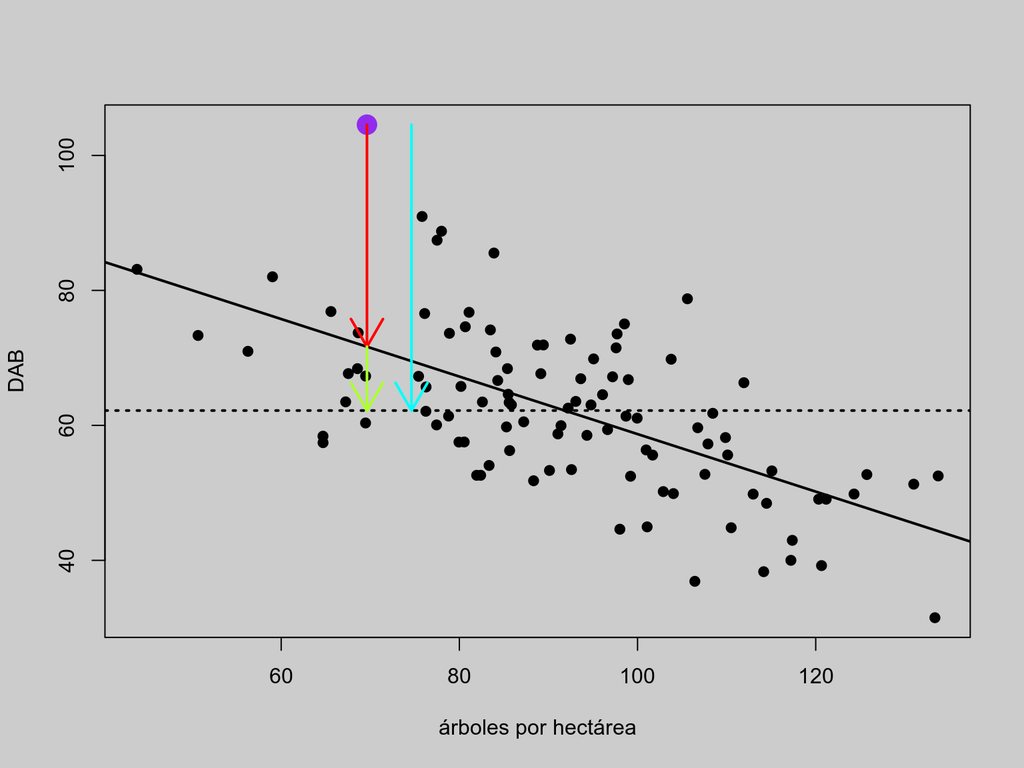

$$\color{greenyellow}{{SS_{modelo}} = \sum(\hat{y_{i}}-\bar{y})^2}$$

$$\color{red}{SS_{residual} = \sum({y_{i}}-\hat{y_{i}})^2}$$

$$\color{cyan}{SS_{total} = \sum({y_{i}}-\bar{y})^2}$$

$$R^2 = \frac{SS_{modelo}}{SS_{total}}$$

$$R^2 = 1 - \frac{SS_{residual}}{SS_{total}}$$

- El $R^2$ nos dice que proporción de la variación de la variable dependiente es explicada por la variación en la variable independiente.
- El $F$ del Anova y su $P$ asociado nos dicen si la porción de la varianza explicada por la regresión es significativa.
- El $t$ y su $P$ asociado indican la significancia del coeficiente de regresión. Esto es, prueban la hipótesis nula de que $\beta = 0$.
- La variable x es **medida sin error**. Es decir es una variable fija.
- **Linealidad**. El valor de y para cada valor de x es descripto por una función lineal.
- **Normalidad**. Para cada valor de x las y son independientes y se distribuyen normalmente. Por lo que… los residuos se distribuyen normalmente.
- **Homogeneidad de varianzas**. La varianza alrededor de la línea de regresión es constante e independiente de los valores de x o y.
- **Independencia**. Los valores de y y los errores son independientes unos de otros.

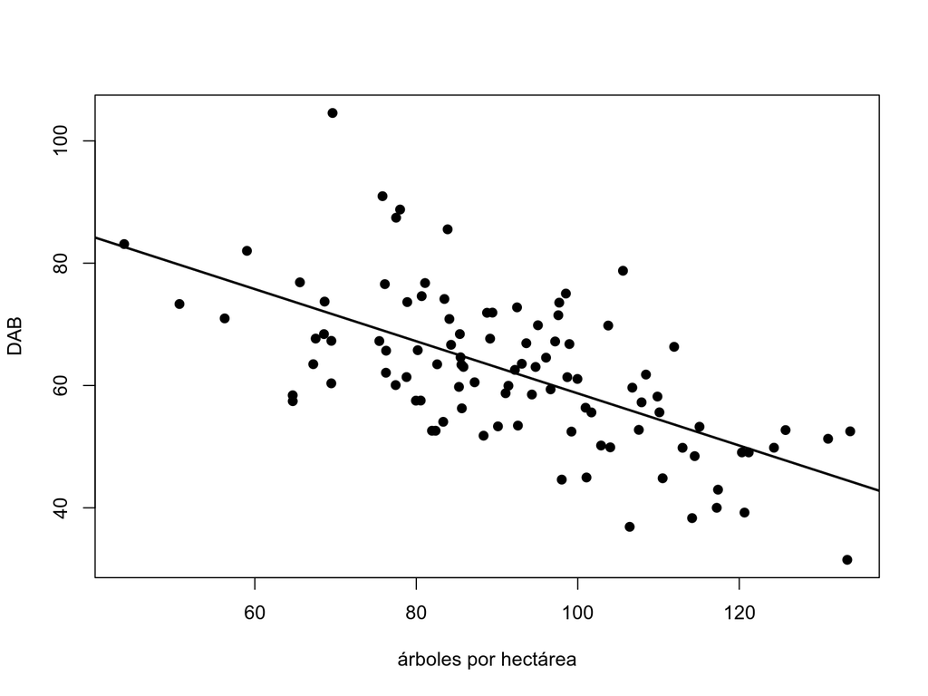

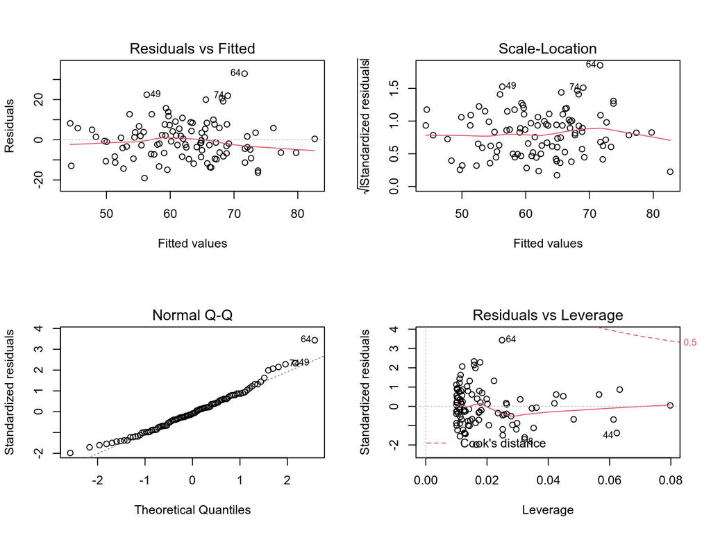

## Influencia

- **Residuos:** miden la distancia desde el valor observado de y hasta la recta de regresión.
- **Leverage:** es una medida de cuan extrema es una observación en x. Detecta outliers en x.
- **Distancia de Cook o influencia:** combinación de las dos anteriores. Si un punto tiene un alto leverage y un gran error, es muy influyente.

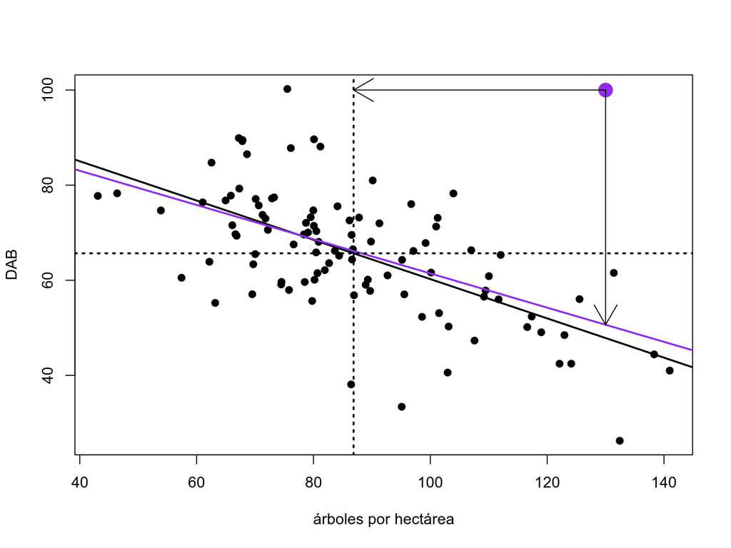

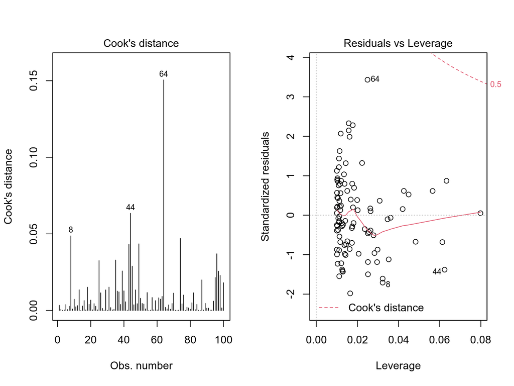

## Análisis de la varianza

$$Y_{ij} = \mu + \alpha_{i} + \epsilon_{ij}$$
* Examinar la contribución relativa de distintas fuentes de variación.
* Probar la hipótesis nula de la media poblacional y las medias para cada nivel del factor son iguales.

### (Pequeña nota histórica)

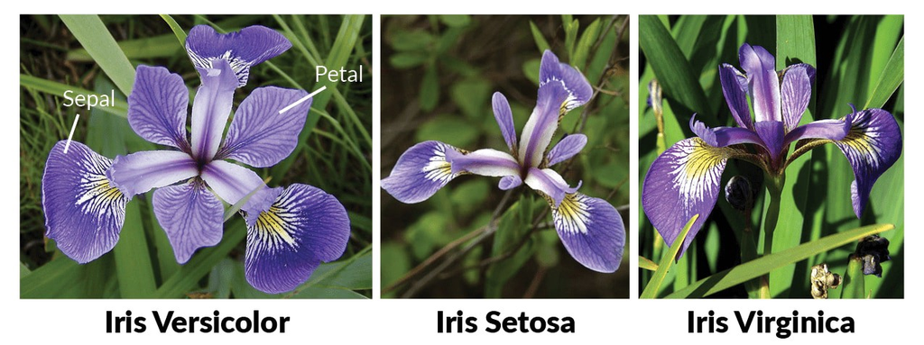

*Iris* fue publicado por primera vez en **1936** por Ronald Fisher en el *Annals of Eugenics*. Proponía una metodología para describir “rasgos deseables” en apoyo al programa eugenésico.

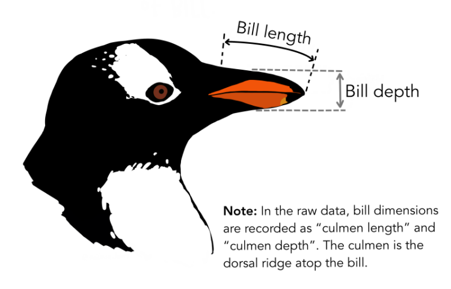

Desde este año voy a usar como ejemplo los datos de pingüinos de tres especies (Adelie, Chinstraw y Gentoo) del Archipiélago de Palmer (Antártida), a traves del paquete *palmerpenguins*.

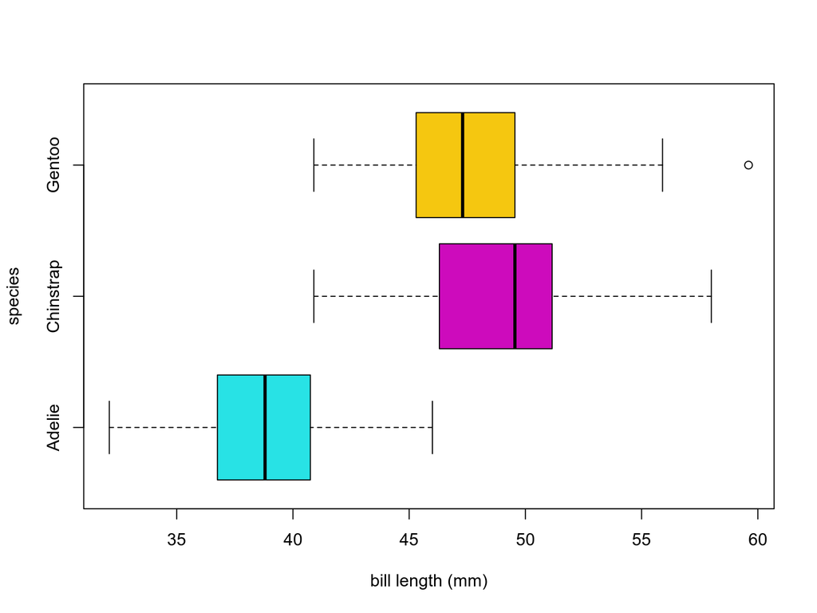

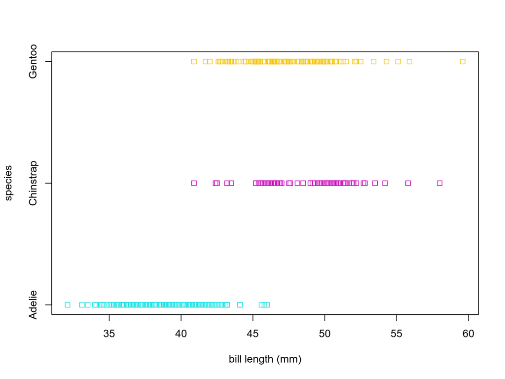

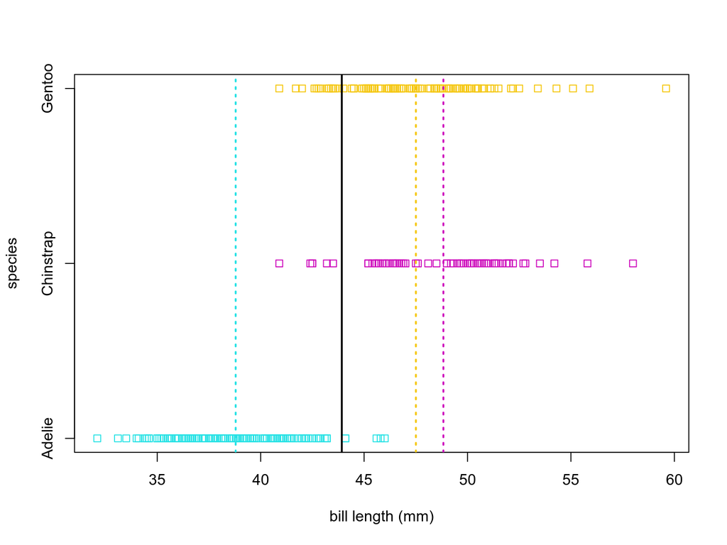

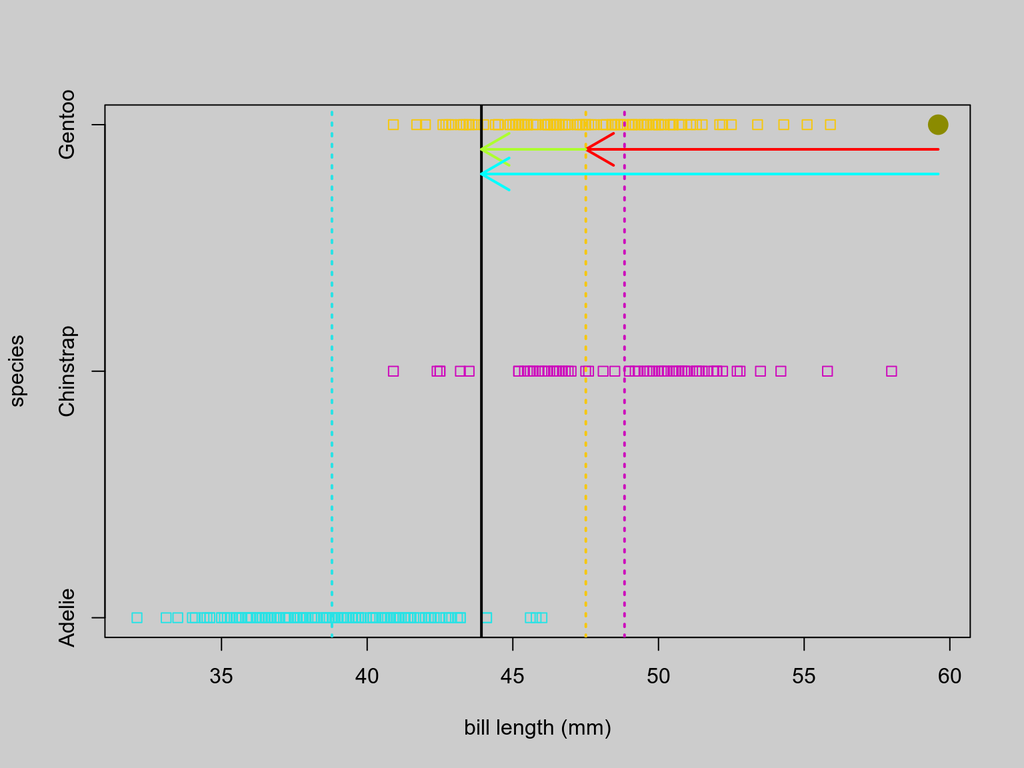

$$\color{greenyellow}{{SS_{modelo}} = \sum(\hat{y_{i}}-\bar{y})^2}$$

$$\color{red}{SS_{residual} = \sum({y_{i}}-\hat{y_{i}})^2}$$

$$\color{cyan}{SS_{total} = \sum({y_{i}}-\bar{y})^2}$$

$$R^2 = \frac{SS_{modelo}}{SS_{total}}$$

$$R^2 = 1 - \frac{SS_{residual}}{SS_{total}}$$

```r
library(palmerpenguins); data("penguins")
fit <- lm(bill_length_mm ~ species, data = penguins)
anova(fit)
```

```
## Analysis of Variance Table
##
## Response: bill_length_mm
##            Df Sum Sq Mean Sq F value    Pr(>F)
## species     2 7194.3  3597.2   410.6 < 2.2e-16 ***
## Residuals 339 2969.9     8.8
## ---
## Signif. codes:  0 '***' 0.001 '**' 0.01 '*' 0.05 '.' 0.1 ' ' 1
```

```r
library(palmerpenguins); data("penguins")
fit <- lm(bill_length_mm ~ species, data = penguins)
summary(fit)
```

```
##
## Call:
## lm(formula = bill_length_mm ~ species, data = penguins)
##
## Residuals:
##     Min      1Q  Median      3Q     Max
## -7.9338 -2.2049  0.0086  2.0662 12.0951
##
## Coefficients:
##                  Estimate Std. Error t value Pr(>|t|)
## (Intercept)       38.7914     0.2409  161.05   <2e-16 ***
## speciesChinstrap  10.0424     0.4323   23.23   <2e-16 ***
## speciesGentoo      8.7135     0.3595   24.24   <2e-16 ***
## ---
## Signif. codes:  0 '***' 0.001 '**' 0.01 '*' 0.05 '.' 0.1 ' ' 1
##
## Residual standard error: 2.96 on 339 degrees of freedom
##   (2 observations deleted due to missingness)
## Multiple R-squared:  0.7078, Adjusted R-squared:  0.7061
## F-statistic: 410.6 on 2 and 339 DF,  p-value: < 2.2e-16
```

### ¿Por qué hay una salida de regresión para un ANOVA?

$$Y_{ij} = \mu + \alpha_{i} + \epsilon_{ij}$$
$$Y_{ij} = \beta_{0} + \beta_{1}X_{i1} + ... \beta_{j}X_{ij} + \epsilon_{ij}$$

### ¿Por qué hay una salida de regresión para un ANOVA?

$$Y_{ij} = \mu + \alpha_{i} + \epsilon_{ij}$$
$$Y_{ij} = \beta_{0} + \beta_{1}X_{i1} + ... \beta_{j}X_{ij} + \epsilon_{ij}$$

### Dummies

1. **dummy 1** Adelie = 0, Chinstrap = 1, Gentoo = 0
2. **dummy 2** Adelie = 0, Chinstrap = 0, Gentoo = 1
3. Si dummy 1 = 0 y dummy 2 = 0, entonces Adelie!

$$Y_{ij} = \beta_{0} + \beta_{dummy1}X_{i1} + \beta_{dummy2}X_{i, dummy2} + \epsilon_{ij}$$

$$Y_{i, Adelie} = \beta_{0} + \epsilon_{ij}$$

$$Y_{i, Chinstrap} = \beta_{0} + \beta_{dummy1} + \epsilon_{ij}$$
$$Y_{i, Gentoo} = \beta_{0} + \beta_{dummy2} + \epsilon_{ij}$$

```r
library(palmerpenguins); data("penguins")
fit <- lm(bill_length_mm ~ species, data = penguins)
summary(fit)
```

```
##
## Call:
## lm(formula = bill_length_mm ~ species, data = penguins)
##
## Residuals:
##     Min      1Q  Median      3Q     Max
## -7.9338 -2.2049  0.0086  2.0662 12.0951
##
## Coefficients:
##                  Estimate Std. Error t value Pr(>|t|)
## (Intercept)       38.7914     0.2409  161.05   <2e-16 ***
## speciesChinstrap  10.0424     0.4323   23.23   <2e-16 ***
## speciesGentoo      8.7135     0.3595   24.24   <2e-16 ***
## ---
## Signif. codes:  0 '***' 0.001 '**' 0.01 '*' 0.05 '.' 0.1 ' ' 1
##
## Residual standard error: 2.96 on 339 degrees of freedom
##   (2 observations deleted due to missingness)
## Multiple R-squared:  0.7078, Adjusted R-squared:  0.7061
## F-statistic: 410.6 on 2 and 339 DF,  p-value: < 2.2e-16
```

- El $R^2$ nos dice que proporción de la variación de la variable dependiente es explicada por la variación en la variable independiente.
- El $F$ del Anova y su $P$ asociado nos dicen si la porción de la varianza explicada por la regresión es significativa.
- El t y su P asociado indican la significancia del coeficiente de la *dummy*. Esto es, si la diferencia entre un tratamiento y el tratamiento (especie) tomado como referencia es significativa.

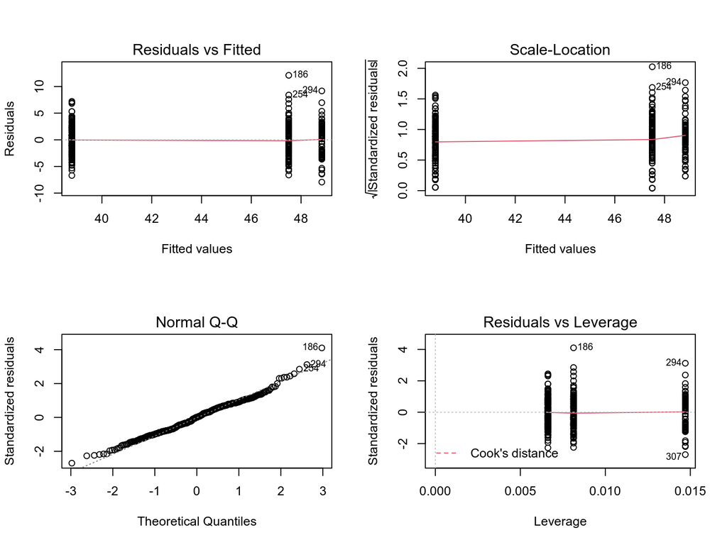

```r
library(palmerpenguins); data("penguins")
fit <- lm(bill_length_mm ~ species, data = penguins, na.action = na.exclude)
shapiro.test(residuals(fit))
```

```
##
##  Shapiro-Wilk normality test
##
## data:  residuals(fit)
## W = 0.98903, p-value = 0.01131
```

```r
bartlett.test(residuals(fit) ~ penguins$species)
```

```
##
##  Bartlett test of homogeneity of variances
##
## data:  residuals(fit) by penguins$species
## Bartlett's K-squared = 5.6179, df = 2, p-value = 0.06027
```

## Training & Test

Datos de entrenamiento y datos de prueba

- Todo nuestro modelado se basa en la minimización de los residuos.
- ¿Son los únicos (o los mejores) residuos disponibles?
- ¿Es el único (o el mejor) modelo para estos datos?
- ¿Qué pasaría si minimizo los residuos *hasta que no quede nada*?

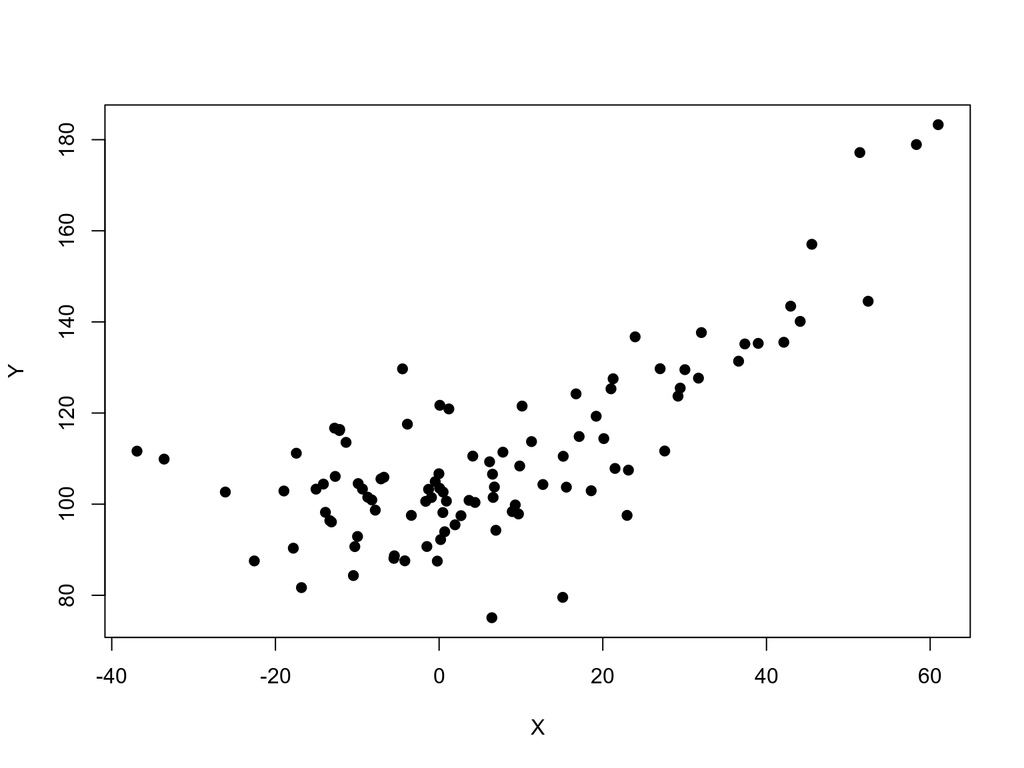

### Modelos sucesivamente más complejos

```r
set.seed(1234)
X <-rnorm(100, mean = 10, sd=20)
Y <- 100 + 0.25*X + 0.019*X^2 + rnorm(100, 0, 10)
fit1 <- lm(Y ~ X)
fit2 <- lm(Y ~ poly(X, 2))
fit3 <- lm(Y ~ poly(X, 10))
summary(fit1)$r.squared #LINEAL
```

```
[1] 0.5408381
```

```r
summary(fit2)$r.squared #CUADRÁTICO
```

```
[1] 0.7319006
```

```r
summary(fit3)$r.squared #POLINOMIO GRADO 10
```

```
[1] 0.7412149
```

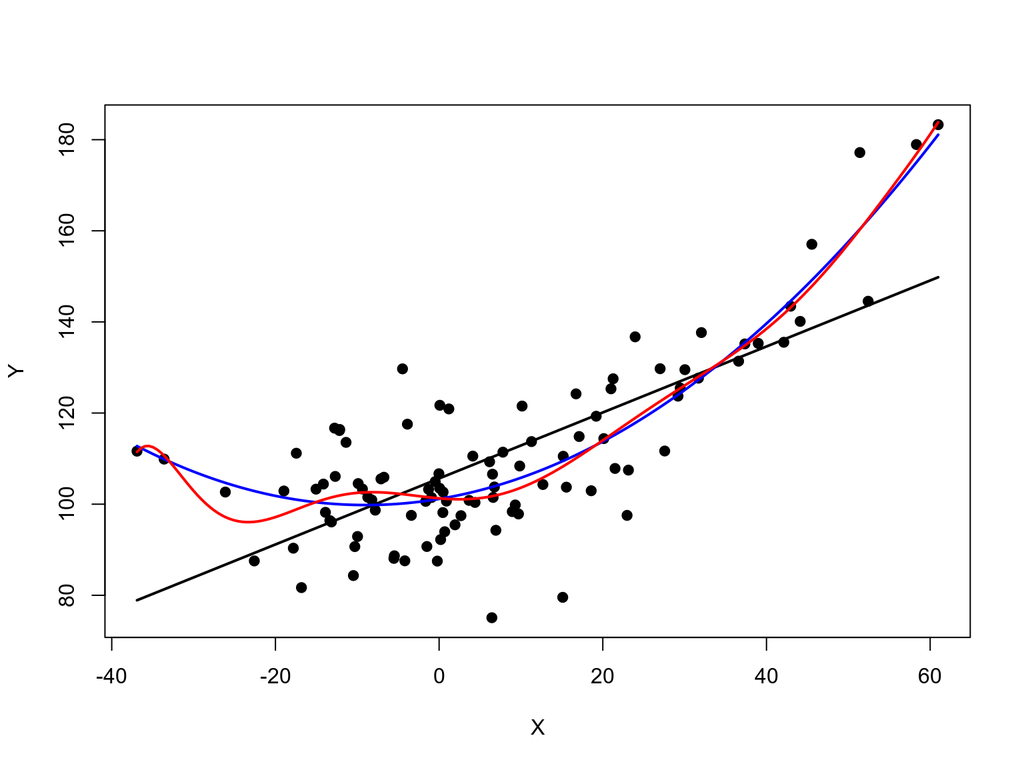

### Training (50 datos)

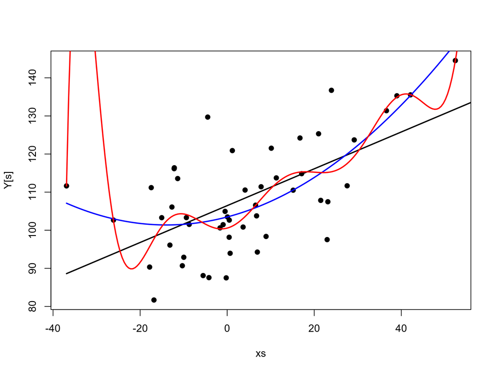

### Test (50 datos)

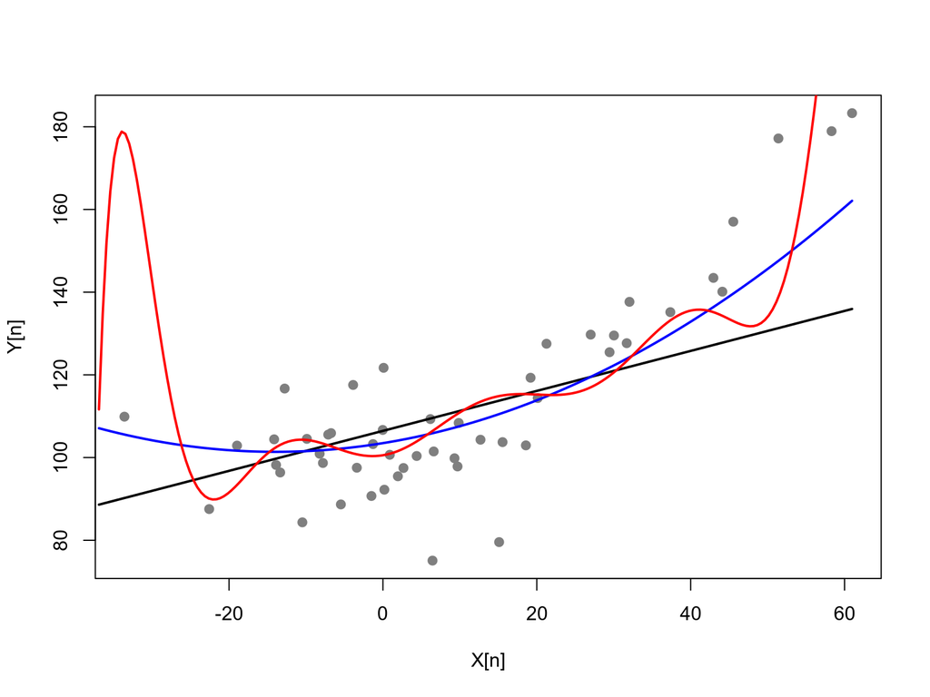

### Test (50 datos). RSSP

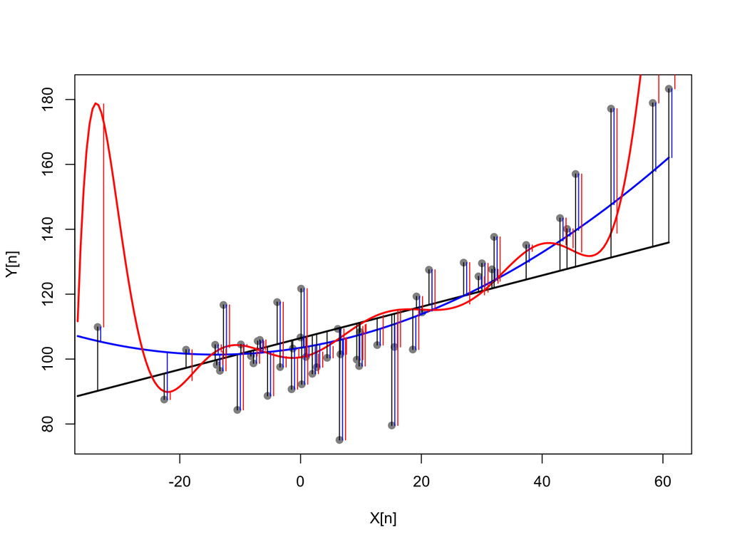

### RSSP

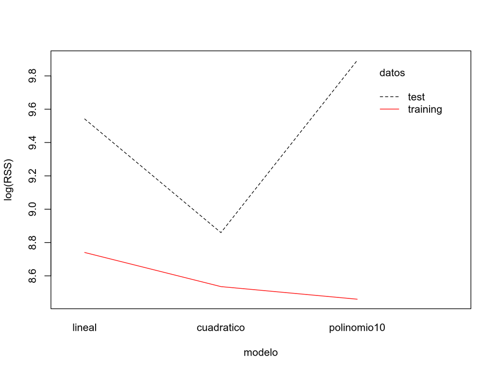